# Energia

15/8/2021

## Analisi dei dati sulla produzione di energia e sulle emissioni di CO2

- La battaglia sulle **energie rinnovabili** sembra non poter essere vinta a causa della nota poca affidabilita' degli impianti "verdi".
- Il vantaggio delle energie rinnovabili, oltre a sostituire fonti di energia come il petrolio la cui disponibilita' diviene sempre piu' limitata, e' quello di ridurre le enormi **emissioni di anidride carbonica**.
- Esistono delle valide alternative alle fonti di energia rinnovabili, come il **nucleare**.
- Lo scopo di questa raccolta ed elaborazione di dati e' quello di scongiurare il luogo comune che l'energia nucleare sia altamente piu' inquinante delle risorse tradizionali.

## Cosa si intende con energia?

Con energia non si intende solo l'energia elettrica prodotta da un impianto ma ogni tipo di energia. Per esempio nel caso del petrolio e dei suoi derivati si considera nel totale dell'energia prodotta anche quella generata dai motori termici delle **automobili**. La stessa considerazione viene fatta per le emissioni.

### **Energia tradizionale**

Si intendono i **combustibili fossili** come il carbone e il petrolio (con tutti i suoi derivati). Consideriamo anche i gas naturali.

### **Energia rinnovabile**

Energia eolica, idroelettrica…

## Produzione di energia dal 1800

Il seguente grafico rappresenta i dati relativi alla produzione di energia di ogni tipo (rinnovabile, tradizionale e nucleare) negli ultimi 200 anni.

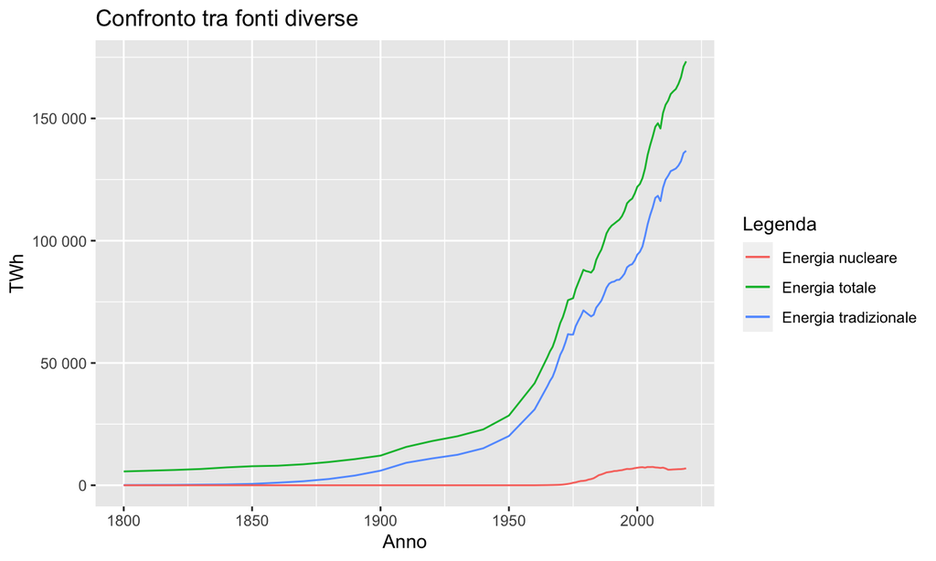

## Energia nucleare

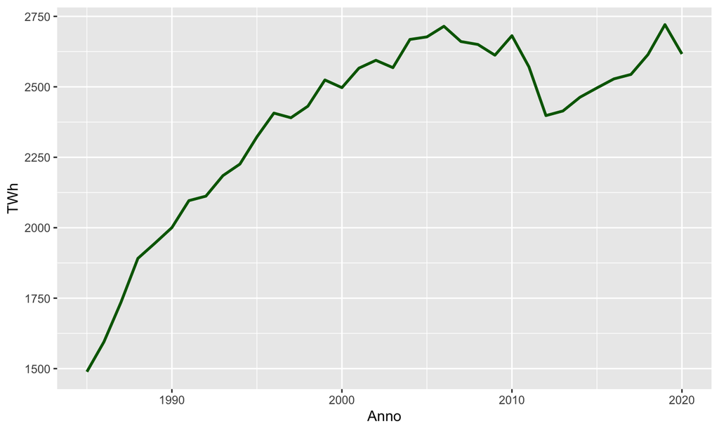

## Considerazioni

Si puo' notare che nel 2020 la produzione di energia nucleare copre solo l'**4,30%** della produzione energetica mondiale. I motivi sono diversi e anche molto complessi da spiegare senza entrare in ambito storico storico e politico.

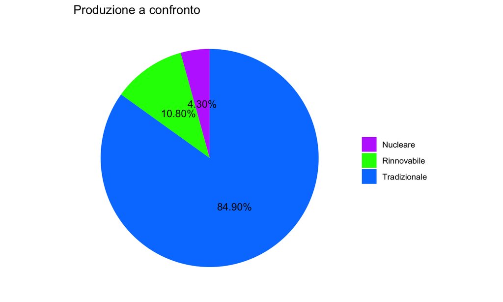

## Emissioni

Il seguente grafico riporta le tonnellate di CO2 per TWh. I dati utilizzati sono stati presi da diverse fonti online, spesso contrastanti, e poi modificati per renderli omogenei.

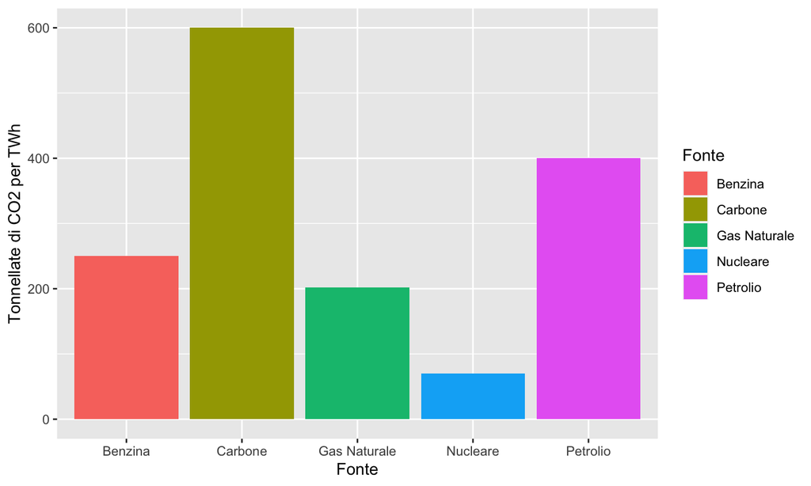

## Un po' di conti

Possiamo calcolare la quantita' di tonnellate di anidride carbonica che sarebbe stata emessa nel tempo, nell'ipotesi in cui tutta l'energia fosse stata prodotta solo ed esclusivamente attraverso impianti nucleari.

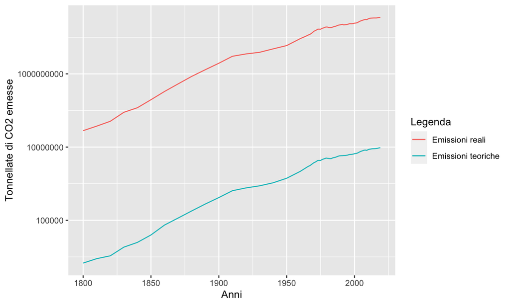

## Il lato negativo del nucleare

Gli svantaggi del nucleare sono:

- Le scorie del combustibile nucleare esaurito hanno dei tempi di smaltimento molto lunghi in base alla loro radioattivita'.
- Il costo di produzione degli impianti e' proibitivo a causa delle normative di sicurezza da rispettare.
- Il materiale nucleare e' limitato, per esempio l'uranio e' un elemento molto raro.

## Le scorie nucleari

I tre tipi di scorie sono:

1. *Bassa attivita'*, necessitano di 20/30 anni per il loro smaltimento, sono il 90% dei rifiuti prodotti dalle centrali.
2. *Media attivita'*, necessitano di 300 anni circa, si tratta delle scorie ottenute dallo smaltimento di vecchie centrali nucleari.
3. *Alta attivita'*, necessitano di *migliaia* di anni e sono il risultato di diversi processi di raffinazione del materiale nucleare grezzo per rendere la resa energetica maggiore, costituiscono il 95% della radioattivita' complessiva.

## Smaltimento

- I metodo di smaltimento del materiale nucleare prevede che il contenimento delle scorie avvenga in appositi contenitori resistenti alla corrosione provocata dalle radiazioni ionizzanti.
- Questi contenitori poi vengono inseriti in dei siti controllati (per scongiurare qualsiasi attivita' terroristica contro l'ambiente) e spesso difficili da raggiungere, come per esempio su fondali oceanici, o sottoterra, in profondita' di formazioni geologiche argillose.
- I contenitori sono diversi a seconda del tipo di scoria.
- Nel caso delle scorie ad alta attivita' per esempio, la riduzione della radioattivita' fino a valori non nocivi richiede centinaia di migliaia di anni, dunque i contenitori (in genere prodotti con particolari leghe di metallo) devono durare nel tempo e non perdere le proprie caratteristiche.

## In conclusione

- Gli ostacoli piu' grandi da superare per la migrazione totale dalle fonti di energia tradizionali al nucleare sono rappresentati soprattutto dai costi per l'allestimento di impianti nucleari a norma.
- Prima o poi questi ostacoli verranno affrontati per la necessita' di ridurre le emissioni in costante crescita anno dopo anno.
- Utilizzando le tecniche e tecnologie di smaltimento delle scorie, potra' essere possibile sfruttare l'energia nucleare per produrre enormi quanita' di energia con poco materiale ed emissioni quasi al pari delle fonti rinnovabili.